# lab2

Lab #2: Probability, Distributions, and Statistical Questions Problem 1

```python
import numpy as np
import matplotlib
import matplotlib.pyplot as plt
import scipy
from scipy import stats
import math
from scipy.stats import poisson
from scipy.stats import rayleigh
from scipy.stats import norm
```

A) Show how the probability distribution of the background changes as you integrate (sum) for more days.

```python
cosmic = 3
gamma = 5
```

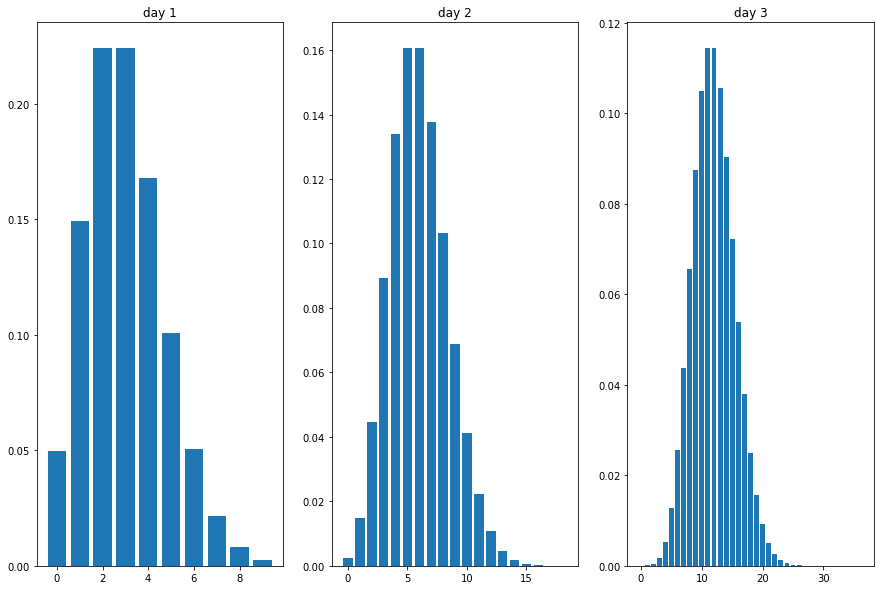

```python
x = np.arange(0,10)
plt.subplot(1, 3, 1)

day1 = stats.poisson.pmf(x,cosmic)
plt.bar(x, day1, fill=True)
plt.title("day 1")

plt.subplot(1, 3, 2)
day2= np.convolve(day1, day1)
plt.bar(range(len(day2)), day2, fill=True)
plt.title("day 2")

plt.subplot(1, 3, 3)
day3= np.convolve(day2, day2)
plt.bar(range(len(day3)), day3, fill=True)
plt.title("day 3")

#as sum for more days, the mean slowly increased. It is also more towards the a gaussian dist.
```

B) Show that after 5 days, the summed probability distribution is still a Poisson distribution. Explain why this makes sense from a mathematical and conceptual point of view.

```
0
1
2
3
4
```

```
<BarContainer object of 55 artists>
```

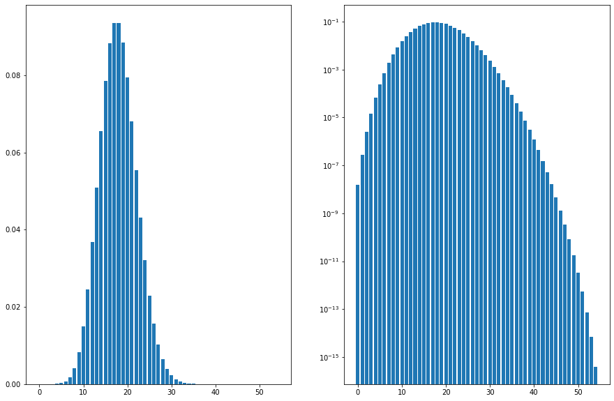

```python
plt.subplot(1, 2, 1)

sum_5 = day1
for i in range(5):
    sum_5 = np.convolve(sum_5, day1)
    print(i)

plt.bar(range(len(sum_5)), sum_5)
plt.subplot(1, 2, 2)
plt.yscale('log')
plt.bar(range(len(sum_5)), sum_5)
```

```python
#this is still a Poisson distribution. After we log the graph we see it is not Gaussian. this make sense. the summ of 5 data
#is only the addition of independent events. The sum of Poisson don't make it Gaussian
```

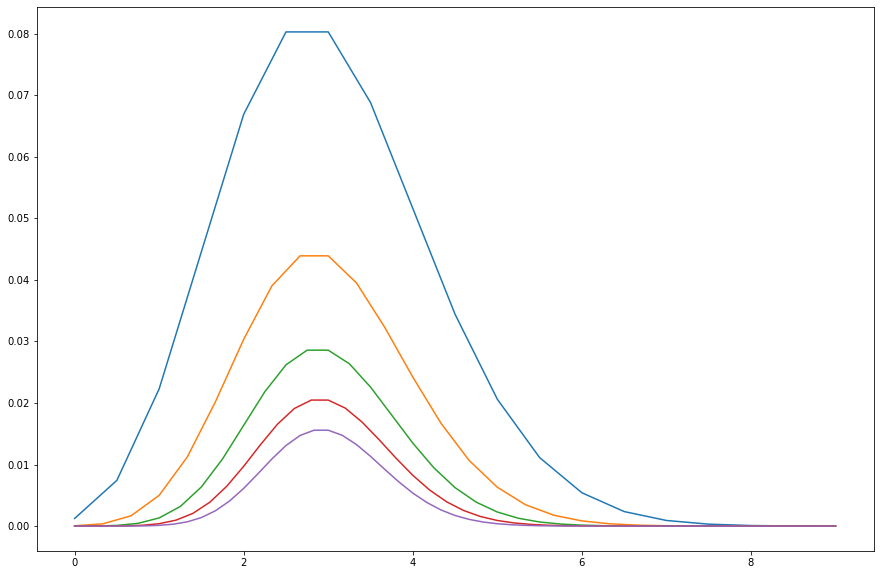

```python
avg = day1

for i in range(5):
    avg= np.convolve(avg, day1)
    x_value=range(len(avg))
    plt.plot([x / (i+2) for x in x_value], avg/(i+2))
```

```python
#this is still a Poisson distribution with less sd. it looks like Gaussian because of central limit therom, more data were
#took. it will become closer to Gaussian. Compared to the sum, the mean doesn't change.
```

D) Pick some number of days N, and assume you saw Y*N gamma rays from your source. Calculate the 'sigma' of your observation.

```python
day = 10
gamma = 5
prob = day1
for i in range(10):
     prob = np.convolve(day1, prob)
p = prob[50:].sum()
stats.norm.ppf(1-p)
#if we choose ten days, and looking for 5 gammas per day. we will looing for possibilities greater than 50. It will be from
#50 to infinity. means the 1-convolved data. then gave us 2.76 sigma.
```

```
2.764507982788788
```

Problem 2¶ Pick a skewed continuous distribtuion, such as a Rayleigh, that describes your background over some observing interval.